```r
# Borra consola, variables y funciones definidas en el entorno Global
rm(list = setdiff(ls(), lsf.str()));
rm(list=lsf.str());
cat("\014") #borra consola
```

```r
#librerías (si R no tiene instaladas, las instala con "install.packages(libreria)")
if(suppressWarnings(library("jpeg", logical.return = T ) == FALSE)) +
{install.packages("jpeg")}

if(suppressWarnings(library("crayon", logical.return = T ) == FALSE)) +
{install.packages("crayon")}
library("jpeg");library("ggplot2");library("crayon");
fig <- function(width, heigth){
 options(repr.plot.width = width, repr.plot.height = heigth)
 }
```

# F Exp I - Clase 1 - Software

# Holas digitales

Yo: Juan Pablo de Rosas (un servidor)

### Listo el pollo:

# Introducción a *R*

### Guión

En esta primera clase veremos algunas caracterı́sticas del lenguaje de programación R, que es un lenguaje de alto nivel orientado a la estadı́stica. Intentaremos familiarizarnos con las operaciones y el método de funcionamiento general, sin intentar recaer en particularidades, a fin de no perder el objetivo final de este curso: leer, analizar e interpretar datos de mediciones.

Para esta primera clase pasaremos revista a algunos tipos de variables (objetos, en general) tı́picas del lenguaje, y la forma de indexarlos. Veremos algunas operaciones entre variables y un puñado de funciones que, operando con las variables, realicen tareas de nuestro interés. Analizaremos brevemente –tal vez demasiado– la idea de algoritmo, intentando comprender cuál es el propósito de realizar uno, y los pasos a seguir. Finalmente daremos una mirada a tres casos especı́ficos de algoritmo, que realizan diferentes tareas.

## Intro

### ¿Qué es R?

- R es un lenguaje de programación, que entra en la clasificación de software libre (por intención manifiesta de/les autores del software, se puede distribuir libremente, modificar, copiar, etc.).
- Está dedicado especı́ficamente a probabilidad/estadı́stica/análisis de datos, motivo por el cual aprenderemos algunas funciones básicas en Fı́sica Experimental I y en Tratamiento de Datos Empı́ricos.
- R fue desarrollado inicialmente por Robert Gentleman y Ross Ihaka del Departamento de Estadı́stica de la Universidad de Auckland en 1993
- Hoy en dı́a **[R es muy utilizado](https://tiobe.com/tiobe-index/)** en el ambito académico y privado.

[figure not shown]

## Intro

### ¿Para qué lo vamos a usar?

- Para hacer y calcular unos modelitos simples que contrastaremos con nuestros experimentos.
- Para hacer análisis de los resultados de los experimentos.
- Para hacer gráficos.
- Para sacar cuentas con fotos (?).

## Intro

### ¿Qué es programar?

*Hacer código* (algoritmos) es dar instrucciones ordenadas a la compu, para que realice una tarea.

- Permite automatizar procesos.
- Permite sacar muchas cuentas rápido y ahorrarnos trabajo manual.
- Permite aprender una forma de pensar que colinda con mate, pero no es idéntica.

*Las instrucciones* dependen del lenguaje, pero todes comparten características comunes (tienen un antepasado común, el FORTRAN). Luego, C, C++, Java, Python, R, Julia, LISP (ojo que este es para matemáticos y no tiene sintaxis parecida a FORTRAN) en fin, hay muchos, muchísimos lenguajes.

## Intro

### ¿Cómo aprendemos a programar?

- La mejor forma de aprender a hacer código es *haciéndolo*.
  - Siempre con un objetivo (acá no vamos a usar Java para hacer aplicaciones de cel, sino vamos a ver, interpretar y cuantificar cosas).
  - Siempre sabiendo que se puede sacar todo de internet.

## Intro

### ¿Cómo aprendemos a programar?

- A veces las personas se desaniman rápido al intentar hacer código:
  - Siempre aprender es engorroso.
  - Al principio parece un cocoliche inentendible.
  - Al comienzo, parece que la *paga* por hacer código es *poca*.

### ¿Cómo aprendemos a programar?

- Consejos de siempre:
  - Es bueno *copipastear* código e intentar modificarlo.
  - Es mejor charlar con alguien que curse que ya tuvo el mismo problema.
  - Si nada de esto funciona, que nos pasen el código hecho (ojo con ir directamente hacia esta opción)

### Intro

#### ¿Cómo aprendemos a programar?

- Haciendo código para una tarea específica #### Comunidad de programadores Hay muchas, para todos los lenguajes disponibles. Yo uso Stack Overflow pero hay muchas más, incluso blogs enteros...
- **[Stack Overflow](https://stackoverflow.com/)** **(de Licencia Creative Commons)*
- **[Git Hub](https://github.com/)** **(propiedad de Microsoft desde hace algún tiempo)**, es un servidor para trabajar en código (repositorios se llaman), pero lo pongo sólo para mostrarles que, si hacen funciones que resuelven algún problema, en cualquier lenguaje, incluso para la arduino, las pueden subir acá.

**El código es más grande que *nuestros* problemas:**

Siempre alguien ya resolvió el problema que tenemos, o uno parecido. O nos da una pista.

**En estas comunidades se puede preguntar cualquier cosa, también se pueden buscar preguntas ajenas. Problemas:**

- Mayormente en inglés: comenzar con un buscador de internet..."How to ...sum up two vectors + R"
- Necesitamos un poco de training para que sea útil...no pueden poner ¿cómo sumo dos vectores en R?

**Hay en español, pero...pero...pero:**

- No tiene muchas entradas $\Rightarrow$ no es tan fácil encontrar *cualquier* problema que tengan.

## ¿Cómo se ve R en el Jupyter Notebook?

Jupyter Notebook (para quienes instalaron Anaconda) es una manera de mezclar código y texto, y es esto que están viendo. Originalmente pensado para Python, ahora tiene soporte para más de 40 lenguajes, así es que piensen que puede serles útil...

Hay *celdas* de texto, como esta. Y *celdas* de código, como la que viene:

```r
print("Hola Mundo"); print("Mundo Inmundo");
```

```
[1] "Hola Mundo"
[1] "Mundo Inmundo"
```

Podemos hacer unas cuentas como una calculadora también:

```r
print(2+3) #calculamos 2 + 3
```

```
[1] 5
```

```r
print(2-3)# 2-3
```

```
[1] -1
```

```r
print(2*3) #acá calculamos 2 por 3
```

```
[1] 6
```

```r
print(3/2) #3/2
```

```
[1] 1.5
```

```r
print(3^2) #tres al cuadrado ó....
print(3**2)#tres al cuadrado
```

```
[1] 9
[1] 9
```

```r
print(sqrt(4)) #una forma alternativa de raíz de 4 ó
print(4**(1/2))#la forma más general
print(4^1/2)
```

```
[1] 2
[1] 2
[1] 2
```

```r
print(2==3) #preguntamos si dos es igual a tres
2==2; #...si dos es igual a dos
#esto es un comentario, no se lee en el código gracias a que usé el símbolo "#"
```

```
[1] FALSE
```

TRUE

Como ven, la salida es una salida un poco árida, pero muestra los resultados que buscábamos.

- Para que la salida se imprima en Jupyter Notebook, tienen que usar `print()` o poner la cuenta o la variable en una línea.
- El código en una celda se corre apretando (`Shift` + `Enter`) ó (`Ctrl` + `Enter`)

### Cosas piolas del notebook

- Cuando ya estén *cancheres*, es una forma muy piola de organizar código explicando cada parte con texto.
- Es piola para que pueda darles estas clases.

### Cosas no tan piolas

- Para quien está aprendiendo es un poco árido, más de lo que pareciera, porque no se ve lo que está cargado en el Entorno (environment) del lenguaje.
- Aparte de esto, hay que aprender a escribir en Markdown para el texto y Látex para las fórmulas, que son los formatos del texto.

## ¿R Studio? R Studio es un *entorno* de programación.

- Está dividido en cuatro partes (dependiendo de si tienen abierto un archivo *.R o no):

[figure not shown]

### Es muy recomendable que usen R Studio para hacer las tareas, pues pueden ver lo que está cargado en el Entorno y no perderse.

Prueben un poco, copipasteando las cuentas que hicimos en la consola, y apretando `Enter` (luego, eh):

```r
print(2+3) #calculamos 2 + 3
```

```
[1] 5
```

```r
sprintf("2 - 3 = %d", 2-3)# 2-3;
sprintf("2 . 3 = 2*3 =  %d", 2*3) #acá calculamos 2 por 3
sprintf("2/3 = %.5f", 2/3) #3/2, con redondeo en 5 cifras decimales
sprintf("3² = 3^2 %d   ó   3² = 3**2 = %d", 3^2, 3**2) #tres al cuadrado ó....
sprintf("Raíz de 4 se escribe: sqrt(4) = %d", 4**(1/2)) #una forma alternativa de raíz de 4 ó
sprintf("Raíz de 4 se escribe: 4^(1/2) = %d", 4^(1/2))#la forma más general
sprintf("¿Dos es igual a 3? se escribe: (2 == 3) = %s", 2==3) #preguntamos si dos es igual a tres
sprintf("¿2 es igual a 2? se escribe: (2 == 2) = %s", 2==2)
print("TRUE = Verdadero, FALSE = Falso (sólo por si no sabía)")
print("La TRUE de la Milanesity")
```

'2 - 3 = -1'

'2 . 3 = 2*3 = 6'

'2/3 = 0.66667'

'3² = 3^2 9 ó 3² = 3**2 = 9'

'Raíz de 4 se escribe: sqrt(4) = 2'

'Raíz de 4 se escribe: 4^(1/2) = 2'

'¿Dos es igual a 3? se escribe: (2 == 3) = FALSE'

'¿2 es igual a 2? se escribe: (2 == 2) = TRUE'

```
[1] "TRUE = Verdadero, FALSE = Falso (sólo por si no sabía)"
[1] "La TRUE de la Milanesity"
```

# Tipos de variables en R

## (Uds acompañan en la consola)

En esta sección veremos algunos tipos de variables que son de común utilización en R. Una variable en un lenguaje de programación es algo parecido -pero no igual- a una variable en matemática. Es un espacio de memoria RAM (de tamaño no definido en este caso) con un nombre como “etiqueta”.

## 1. Vectores atómicos

Probemos guardar cinco números enteros en la variable “vector1”, escribiendo en la consola:

```r
vector1 = c(1,2,3,4,5); vector1 #separar comandos con ";" en la misma línea
```

1. 1

2. 2

3. 3

4. 4

5. 5

en vez de usar el sı́mbolo "`=`" (que se puede), es preferible escribir dos sı́mbolos (`<-` ó `->`) que lo reemplazan, simulando una flecha (también es posible escribir `c(1,2,3,4,5) -> vector1`. El signo igual sólo asigna a izquierda; las flechitas son más *oportunistas*.

Por otra parte, la función `c()` (concatenar) es muy usada, y sirve para crear vectores de números (enteros,decimales y complejos), letras ("charater") o caracteres lógicos ("logical"). A esas listas las llamamos, tengan el tamaño que tengan, *vectores atómicos*.

```r
logicobeibi <- c(TRUE,TRUE,TRUE, FALSE, TRUE); #defino un vector
cat("logicobeibi = (", logicobeibi,"); class: " ,class(logicobeibi)) #imprimimos vector y clase
cat("\n\nvector1 = (", vector1,"); class: " ,class(vector1))
minombre <- c("J", "u", "a", "n"); cat("\n\nminombre = (", minombre,"); class: " ,class(minombre), "\n\n")
cat(bold$blue(paste0(minombre, collapse = "")))
```

```
logicobeibi = ( TRUE TRUE TRUE FALSE TRUE ); class:  logical

vector1 = ( 1 2 3 4 5 ); class:  numeric

minombre = ( J u a n ); class:  character

Juan
```

Se puede *coercionar* un tipo a otro...siempre que tenga sentido.

Por ejemplo: Los enteros ahorran mucha memoria, y `vector1` está definido como `numeric` (número con cifras decimales). Para coercionarlo a un entero (`integer`), le decimos:

```r
vector1 <- as.integer(vector1) #ojo que asignamos a la misma variable, cosa que en mate no se hace
class(vector1); vector1
```

'integer'

1. 1

2. 2

3. 3

4. 4

5. 5

Por otra parte existe una medida especial de la cantidad de elementos contenidos en un vector atómico. Esto se denomina length() (longitud, en inglés):

```r
cat("vector1 =", vector1, ", tiene", length(vector1), " elementos\n")
cat("\nminombre =", minombre, ", tiene", length(minombre), " elementos\n")
cat("\nlogicobeibi =", logicobeibi, ", tiene", length(logicobeibi), " elementos\n")
```

```
vector1 = 1 2 3 4 5 , tiene 5  elementos

minombre = J u a n , tiene 4  elementos

logicobeibi = TRUE TRUE TRUE FALSE TRUE , tiene 5  elementos
```

Para dejar todos los vectores del mismo largo, *me hago un nombre de fantasía para el viernes a la noche vestido de drag queen* (obvio con barbijo):

```r
minombre <- c(minombre, "a") #acá concatenamos un vector con un elemento "a"
cat(strikethrough(bold(red(paste0(minombre, collapse = "") ))));length(vector1);length(minombre);length(logicobeibi)
```

```
Juana
```

5

5

5

[figure not shown]

## 1.1 Indexación de vectores atómicos

- Se pueden *invocar* algún(os) elemento(s) de un vector.
- Esto se llama indexación (de índice, el dedo que apunta)
- Las indexaciones van entre corchetes `[]` al lado de la variable. Ej: `vector1[3]`, el tercer elemento de `vector1`

### 1.1.1 Indexar por números

```r
vector1[1]; minombre[1]; logicobeibi[1]
```

1

'J'

TRUE

### 1.1.2. Indexar varios elementos con vectores de enteros

```r
indpar <- c(2,4); indimpar <- c(1,3,5);
print("Índices Pares: Elementos del vector en posiciones pares")
vector1[indpar]; minombre[indpar]; logicobeibi[indpar];
print("Índices Impares: elementos del vector en posiciones impares")
vector1[indimpar]; minombre[indimpar]; logicobeibi[indimpar]
```

```
[1] "Índices Pares: Elementos del vector en posiciones pares"
```

1. 2

2. 4

1. 'u'

2. 'n'

1. TRUE

2. FALSE

```
[1] "Índices Impares: elementos del vector en posiciones impares"
```

1. 1

2. 3

3. 5

1. 'J'

2. 'a'

3. 'a'

1. TRUE

2. TRUE

3. TRUE

Ojo que el orden importa:

```r
minombreroto <- c(minombre[indpar], minombre[indimpar]); minombreroto
```

1. 'u'

2. 'n'

3. 'J'

4. 'a'

5. 'a'

### 1.1.3. Indexar por condiciones lógicas

```r
vector1 > 3; #el resultado es un vector lógico del mismo largo de vector1
```

1. FALSE

2. FALSE

3. FALSE

4. TRUE

5. TRUE

```r
vector1[vector1 >3] # ">" mayor que 3
```

1. 4

2. 5

```r
vector1[vector1 == 2] # "==" igual a (dos signos seguidos es para comparar)
```

2

```r
vector1
vector1[(vector1 == 2) | (vector1 > 3)] # "|" es el "ó" lógico (igual a 2 ó mayor que 3)
```

1. 1

2. 2

3. 3

4. 4

5. 5

1. 2

2. 4

3. 5

```r
vector1[(vector1 <4) & vector1 > 2]# "&" es el "y" lógico (menor que cuatro y mayor que 2)
```

3

```r
logicobeibi
vector1[logicobeibi]
```

1. TRUE

2. TRUE

3. TRUE

4. FALSE

5. TRUE

1. 1

2. 2

3. 3

4. 5

## 1.2 Operaciones con vectores atómicos

### 1.2.1 Suma

- Al sumar un número a `vector1` obtenemos cada elemento incrementado:

```r
print(vector1)
print(vector1 + 1)
```

```
[1] 1 2 3 4 5
[1] 2 3 4 5 6
```

- Al sumar un vector se obtiene la suma de los elementos 1 a 1 si el vector es del mismo largo:

```r
sumamos <- c(5,4,3,2,1)
print(vector1 + sumamos)
```

```
[1] 6 6 6 6 6
```

¿Por qué pasa lo anterior?

Recordamos la famosa suma rápida de enteros de WF Gauss:

**Gauss, la series matemáticas más rápidas del oeste** El profesor debe ir a hacer burocracia a la oficina del director; a fines de intentar cierta calma, pide que cada estudiante realice la suma de los primeros 100 enteros...esto equivale a: 0 + 1 + 2 + 3 + ... + 100 Uno de los estudiantes tiene la respuesta antes de que el profesor logre salir de la sala. Ese niño era WF Gauss. **¿Cuánto da la suma de los primeros 100 enteros?**

```r
de1a50 <- seq(1,50,1) #función seq() hace vectores que son secuencias "seq(desde,hasta, paso)"
de100a51 <- seq(100,51,-1) #pasos negativos en seq
suma <- de1a50+ de100a51; suma <- data.frame(de1a50 = de1a50, de100a51 = de100a51, suma = suma);
head(suma, 10)
50*101 == sum(suma$suma) #sum()suma todos los elementos de un vector
cat(bold$red("Ya sumé profe...me da", 50*101))
cat(bold$blue("\nYa sumé profe...me da", sum(suma$suma)))
cat(bold$green("\n¿Alguien dice cuánto vale la suma desde 1 a 200? Sale chocolate"))
```

A data.frame: 10 × 3

|  | de1a50 <dbl> | de100a51 <dbl> | suma <dbl> |
| --- | --- | --- | --- |
| 1 | 1 | 100 | 101 |
| 2 | 2 | 99 | 101 |
| 3 | 3 | 98 | 101 |
| 4 | 4 | 97 | 101 |
| 5 | 5 | 96 | 101 |
| 6 | 6 | 95 | 101 |
| 7 | 7 | 94 | 101 |
| 8 | 8 | 93 | 101 |
| 9 | 9 | 92 | 101 |
| 10 | 10 | 91 | 101 |

TRUE

```
Ya sumé profe...me da 5050
Ya sumé profe...me da 5050
¿Alguien dice cuánto vale la suma desde 1 a 200? Sale chocolate
```

## 1.2.2 Multiplicación

- Multiplicar un vector por un escalar nos entrega cada uno de los elementos multiplicados por el escalar:

```r
vector1 <- seq(1,5,1)
cat("    vector1  = ",vector1);
cat("\n2 * vector1  = ",2*vector1);
cat("\n3 * vector1  = ",3*vector1);
```

```
    vector1  =  1 2 3 4 5
2 * vector1  =  2 4 6 8 10
3 * vector1  =  3 6 9 12 15
```

- Multiplicar dos vectores del mismo largo, nada tiene que ver con álgebra. Se multiplican elemento a elemento:

```r
vector2 <- c(6,7,8,9,10);
cat("vector1 * vector2 = (", vector1, ") * (",vector2, ") = ", vector1*vector2)
```

```
vector1 * vector2 = ( 1 2 3 4 5 ) * ( 6 7 8 9 10 ) =  6 14 24 36 50
```

- Si tenemos un vector más corto, se multiplica, pero nos avisan con un *warning* sie el vector grande tiene un número de elementos que no es múltiplo entero:

```r
vcorto <- c(1,2);
vector1 * vcorto
vector1
vcorto
```

```
Warning message in vector1 * vcorto:
“longitud de objeto mayor no es múltiplo de la longitud de uno menor”
```

1. 1

2. 4

3. 3

4. 8

5. 5

1. 1

2. 2

3. 3

4. 4

5. 5

1. 1

2. 2

¿Alguien explica qué operaciones hizo el lenguaje?

## 2. Matrices

Las matrices en `R` son idénticas (en cuanto arreglo) a las del álgebra: un arreglo de números en filas y columnas. Para escribir una matriz, deberemos escribir los elementos y el número de filas (`nrow`) y columnas (`ncol`):

```r
M <- matrix(c(1:9), nrow = 3, ncol = 3, byrow = T);show(M)
```

```
     [,1] [,2] [,3]
[1,]    1    2    3
[2,]    4    5    6
[3,]    7    8    9
```

*Indexar* matrices es muy parecido a como lo hacíamos con los vectores, sólo que:

- Entre los corchetes usamos filas y columnas: `[filas, columnas]`
- Si queremos indicar *todas las filas (o columnas)* dejamos un espacio en blanco, por ejemplo, seleccionar la tercera columna de M, se escribe `M[ , 3]`

```r
M[ ,3]
```

1. 3

2. 6

3. 9

*Al indexar con condiciones lógicas* se obtienen matrices de valores TRUE/FALSE:

```r
M > 3
M[M > 3] #pierde la estructura de matriz
M * (M > 3) #coerciona a la manera de Boole T = 1; F = 0
```

A matrix: 3 × 3 of type lgl

| FALSE | FALSE | FALSE |
| --- | --- | --- |
| TRUE | TRUE | TRUE |
| TRUE | TRUE | TRUE |

1. 4

2. 7

3. 5

4. 8

5. 6

6. 9

A matrix: 3 × 3 of type int

| 0 | 0 | 0 |
| --- | --- | --- |
| 4 | 5 | 6 |
| 7 | 8 | 9 |

- Las operaciones de sumar, restar, multiplicar, dividir, etc. se realizan de la misma manera que con los vectores, i.e., las operaciones se realizan entre pares de elementos con el mismo ı́ndice. Podrı́amos probar multiplicando dos matrices pequeñas.
- Por último, para saber la cantidad de columnas en la matriz M, podemos escribir “ncol(M)”. Para el número de filas, “nrow(M)”. Para el número de filas y el de columnas, “dim(M)”, lo que nos entrega un vector con dos elementos que son el número de filas y de columnas.

```r
ncol(M); nrow(M); show(dim(M))
```

3

3

```
[1] 3 3
```

## 3. Data Frames

Los dataframes son la forma de almacenar datos más “amena” de este lenguaje. Un data frame (una traducción posible serı́a “marco de datos”) es un arreglo de números del mismo estilo que una matriz. Sin embargo posee algunas caracterı́sticas distintivas:

- Las columnas pueden poseer tipos diferentes de variables (por ejemplo, la primera columna puede estar compuesta por caracteres, la segunda por números, etc...).
- Cada columna puede poseer un nombre, lo que hace más fácil el manejo de datos, aunque también podemos indexar, como en las matrices o en los vectores atómicos, utilizando números entre corchetes.
- Generalmente vamos a cargar datos de este tipo a partir de archivos, pero por ahora vamos a hacer uno nosotres a mano.

```r
#definimos cuatro vectores
nombre <- c("Juan Pablo de Rosas", "Ricardo Rubén", "Roberto Carlos");
edad <- c(38,25, 77)
hijes <- c(1, NA, 4) #Ricardo Rubén no se sabe cuántos hijes tiene
amigues <- c(NA, NA, 10^6)

#los juntamos en el data.frame "tabla"
tabla <- data.frame(Nombre = nombre, Años = edad, hijos_as = hijes, Amigos = amigues)
head(tabla, 3)
```

A data.frame: 3 × 4

|  | Nombre <fct> | Años <dbl> | hijos_as <dbl> | Amigos <dbl> |
| --- | --- | --- | --- | --- |
| 1 | Juan Pablo de Rosas | 38 | 1 | NA |
| 2 | Ricardo Rubén | 25 | NA | NA |
| 3 | Roberto Carlos | 77 | 4 | 1e+06 |

en un dataframe se pueden invocar las columnas por el nombre:

```r
tabla$Años
tabla$Años*2 #se pueden hacer las mismas operaciones que con cualquier otro vector
tabla$Nombre * 2 #(ojo que los nombres no se pueden multiplicar como el número de les hijes )
```

1. 38

2. 25

3. 77

1. 76

2. 50

3. 154

1. <NA>

2. <NA>

3. <NA>

Info General:

**[Ricardo Ruben](https://youtu.be/8NH4YfqrB8o)**

**[Roberto Carlos](https://youtu.be/Vh5LsuNPqPU)**

música de jaig cuáliti.

## Valores especiales

Si bien, en principio, es posible utilizar cualquier nombre para una variable, hay combinaciones de caracteres especiales, que refieren a funciones o a palabras reservadas por el lenguaje para funciones especı́ficas. Algunas de ellas son:

- `TRUE` y `FALSE` son los valores lógicos, reemplazables por `T` y `F`.
- `NA` quiere decir Not Available (no disponible), y es una palabra reservada.
- `Inf` es el símbolo para indicar infinito, tiene semejanzas con la matemática, pero en este tipo de lenguajes se obtiene como resultado de *saturar* la cantidad de números posibles...sumar números muy grandes puede entregar este símbolo. 1/0, -1/0, etc. dan `Inf`.
- `NaN` (Not a Number) indica que No es un Número....y se obtiene de hacer `Inf * 0`, `Inf/Inf`, etc...

# Algoritmo - Una discusión torpe y rápida

“Un algoritmo es una conjunto sistemático de procedimientos –en un número finito de pasos– que responden a una pregunta o solucionan un problema. El nombre deriva de la publicación latina Algoritmi de numero Indorum, (“al-Khwuarizmi: Sobre el arte hindú para calcular”) que es una traducción del libro escrito por el matemático musulmán del S. IX al-Khwarizmi"

Fuente: **[Enciclopedia Britannica](https://www.britannica.com/science/algorithm)**

Entonces, un algoritmo es una receta, sin ambiguedades.

[figure not shown]

Cuando algo no funciona bien, decimos que un algoritmo tiene un *bug* (bicho, en inglés). Si bien era utilizado raramente, el término se hizo muy popular gracias a **[Grace Hooper](https://en.wikipedia.org/wiki/Grace_Hopper)** una científica y militar estadounidense, pionera en el campo de la computación, que descubrió que una de sus computadoras (electromecánicas) no funcionaba correctamente, por causa de una polilla en el interior del aparato...que quedó eternizada en el cuaderno del laboratorio de la *Harvard University*.

[figure not shown]

## Algoritmo en R

Para hacer un algoritmo en R:

- Generar un archivo de texto (generalmente es de extensión *.R), conteniendo líneas de código (instrucciones del lenguaje). *Esto se ve arriba a la izquierda en R Studio*
- Luego utilizando el botón “`Source`”, R ejecutará secuencialmente (de la primera a la última) nuestro código. Cada línea debe estar libre de errores de redacción (no se va a interpretar nada que esté mal escrito), por lo que puede resultar una tarea, al principio, muy engorrosa.
- Para ejecutar una lı́nea o una parte de un código, es posible:
  - a) seleccionar una parte del código y presionar el botón Run, al lado de Source
  - b) poner el cursor en una lı́nea y apretar Ctrl + ENTER. Ejecutar pedazos o lı́neas de un código es importante para hacer debugging (desenbichado, en inglés), es decir, en criollo, encontrar los posibles errores del código.

# Ejemplos de Algoritmos

### 1. Ángulo entre vectores (un ejemplo simple )

Como ejemplo simple ponemos el cálculo del ángulo entre dos vectores. Un diagrama de flujo es un gráfico que conecta "bloques" de un código.

Por ejemplo, ¿qué necesitamos hacer para calcular el ángulo entre dos vectores?

Sabemos que, dados dos vectores $\vec{a}$ y $\vec{b}$, el ángulo $\alpha$ entre ellos estará dado por:

$$ \alpha = cos^{-1}\Bigg(\frac{\vec{a} \cdot \vec{b} } {|\vec{a}| |\vec{b}|} \Bigg) $$

Entonces, para saber el ángulo $\alpha$, necesitamos:

1. **`Dos vectores de entrada (Input de nuestro código)`** $\Rightarrow$ 2. **`Calcular el producto punto entre los vectores`** $\Rightarrow$ 3. **`Calcular el módulo de cada vector`**$\Rightarrow$4. **`Dividir el producto punto por el producto de los módulos`**$\Rightarrow$ 5. **`Calcular al arco coseno del resultado anterior`** $\Rightarrow$ 6. **`Expresar el resultado en radianes y grados sexagesimales`**

```r
# 1. Dos vectores de entrada
a <- c(1,0,1); b <- c(1,0,-1)
#2. Calcular el producto punto
prodpunto <- sum(a*b)
#3. Modulos
mod.a <- sqrt(sum(a^2)); mod.b <- sqrt(sum(b^2));
#4. Dividir prodpunto por (mod.a * mod.b)
p <- prodpunto/(mod.a*mod.b)
#5. calcular el arco coseno de p
alpha <- acos(p)
#6. Expresar el resultado en radianes y grados sexagesimales
cat(bold$blue("El ángulo entre a  y b  es de", alpha, "rad"))
cat(bold$red("\nEl ángulo entre a y b es de", alpha*180/pi, "°"))
```

```
El ángulo entre a  y b  es de 1.5707963267949 rad
El ángulo entre a y b es de 90 °
```

### 2. Superficie plana de una mano.

La idea es estimar la superficie de una mano (la mía, que es una mano morena).

Para esto:

1. Saco una foto de mi mano sobre una hoja A4 (29.7 x 21 cm)
2. Usamos el contraste (distinguimos negro de blanco) para seleccionar píxeles.
3. Sabiendo el número de píxeles de la mano respecto del total, calculamos la superficie plana de mi mano.

Esto se ve más o menos como sigue:

```r
####ESPECIFICAR CARPETA DE TRABAJO
setwd("/home/juan/Documentos/Docencia/fexpi/2020/NTB/1.rintro/tex1/Archivos/")
#leemos el archivo de escala de grises (0 = negro/ 1 = blanco/ 0< grises <1)
#Si no está en enscala de grises no va a funcionar...
mano <- readJPEG('mano.jpg') #cargamos la imagen
mano <- as.matrix(mano[,,1]) #la hacemos una matriz
```

Una foto en escala de grises es una *matriz* de números (0 = negro,0 < grises < 1, 1 = blanco) que forman la imagen *digital*:

```r
mano[125:130, 85:95] #los más chiquitos, más cerca del negro, parecidos a uno, cerca del blanco
```

A matrix: 6 × 11 of type dbl

| 0.3607843 | 0.3450980 | 0.3372549 | 0.3333333 | 0.3490196 | 0.6274510 | 0.9411765 | 0.9098039 | 0.9098039 | 0.9098039 | 0.9098039 |
| --- | --- | --- | --- | --- | --- | --- | --- | --- | --- | --- |
| 0.3686275 | 0.3490196 | 0.3372549 | 0.3372549 | 0.3333333 | 0.5960784 | 0.9411765 | 0.9137255 | 0.9137255 | 0.9137255 | 0.9098039 |
| 0.3725490 | 0.3529412 | 0.3411765 | 0.3372549 | 0.3372549 | 0.5725490 | 0.9333333 | 0.9137255 | 0.9137255 | 0.9137255 | 0.9098039 |
| 0.3764706 | 0.3529412 | 0.3450980 | 0.3372549 | 0.3411765 | 0.5450980 | 0.8901961 | 0.9176471 | 0.9137255 | 0.9137255 | 0.9137255 |
| 0.3803922 | 0.3568627 | 0.3490196 | 0.3411765 | 0.3450980 | 0.5294118 | 0.8627451 | 0.9176471 | 0.9137255 | 0.9098039 | 0.9137255 |
| 0.3921569 | 0.3686275 | 0.3411765 | 0.3372549 | 0.3333333 | 0.4823529 | 0.8196078 | 0.9215686 | 0.9176471 | 0.9058824 | 0.9215686 |

```
[1] 0.1019608 1.0000000
```

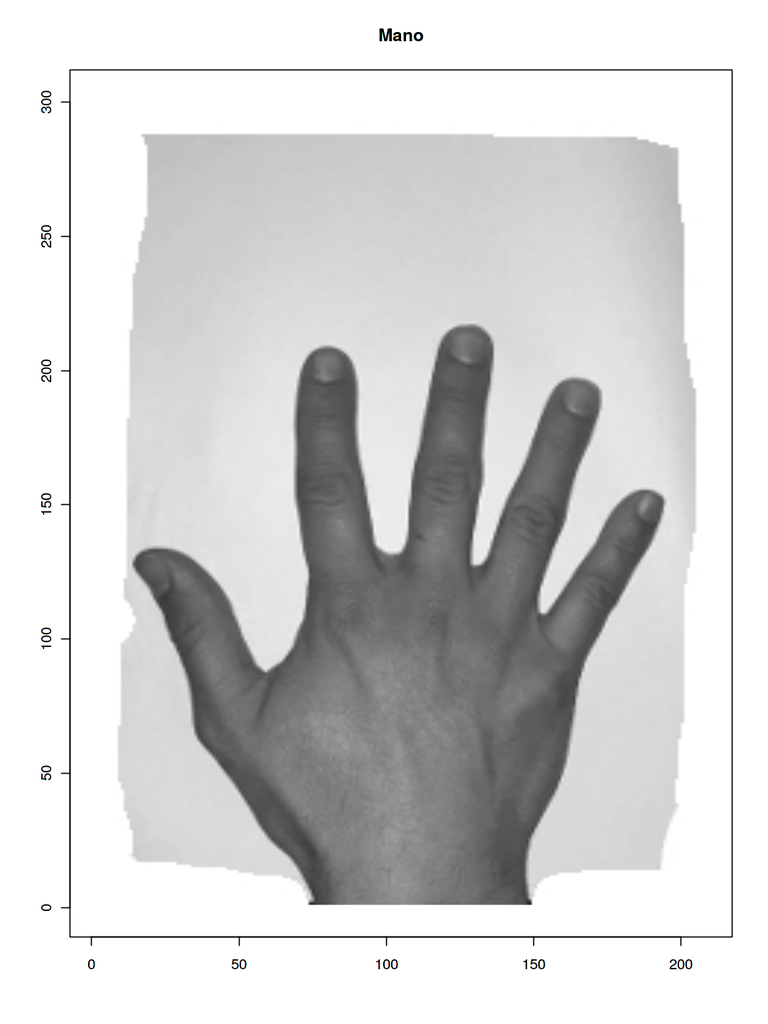

```r
#### Ploteo de imágenes#############
fig(width = 9, heigth = 12);plot(c(1,ncol(mano)) , c(1,nrow(mano)) , type = "n", main = "Mano", xlab = "", ylab = "" )
rasterImage(image = mano, xleft = 1, ybottom = 1, xright = ncol(mano), ytop = nrow(mano))
show(range(mano))
```

Elegimos un valor de contraste para *seleccionar* los píxeles de la mano, que son más oscuritos que el resto. Para esto vemos un lindo histograma:

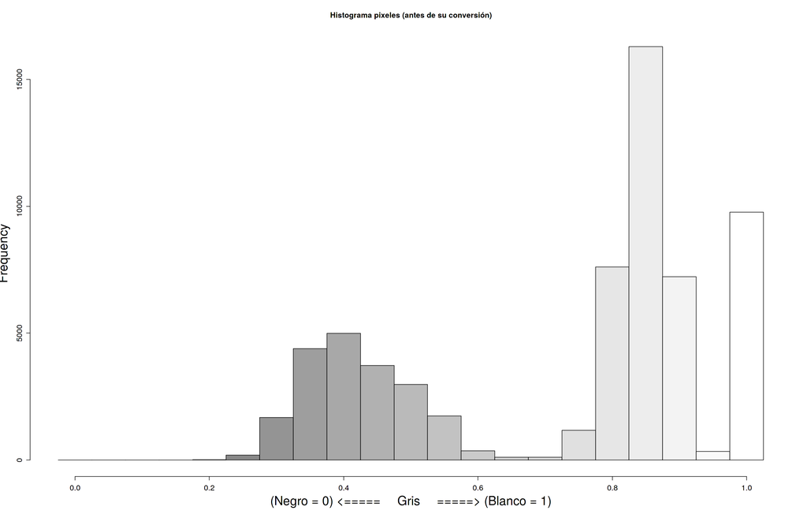

```r
fig(width = 22, heigth = 14)
hist.orig <- hist(mano, main = "Histograma pixeles (antes de su conversión)",
breaks = (b <- seq(-0.025,1.025,0.05)), col = grey.colors(length(b)-1, start = 0,end = 1), xlab = "(Negro = 0) <=====     Gris     =====> (Blanco = 1)",cex.axis = 1.25 ,cex.lab = 2 , plot = T )
```

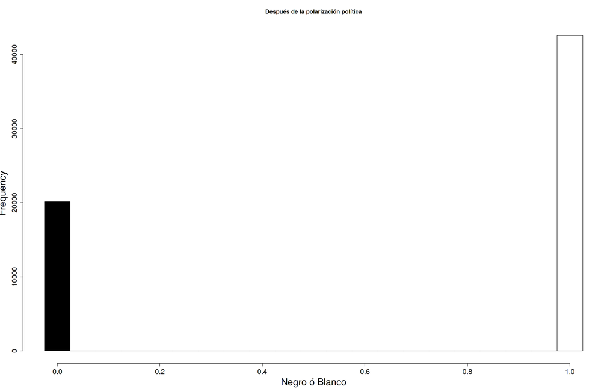

```r
manosaturada <- !(mano < 0.65) #establecemos un límite de gris para la mano
storage.mode(manosaturada) <- "numeric" #pasa de logico a numerico T = 1, F = 0
hist(manosaturada, breaks = seq(-0.025,1.025, 0.05), col = c("Black","White" ,"White"), xlab = "Negro ó Blanco", cex.axis = 1.5, cex.lab = 2 ,main = "Después de la polarización política", probability = F)
```

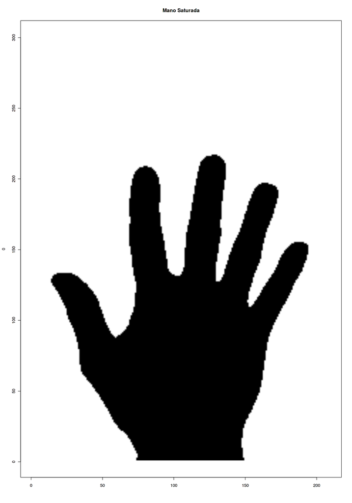

```r
manosaturada <- !(mano < 0.65) #establecemos un límite de gris para la mano
storage.mode(manosaturada) <- "numeric" #pasa de logico a numerico T = 1, F = 0
####PLOTEO de SELECCIóN
#si no vemos todo el contorno negro, sería mejor aumentar el contraste
fig(width = 14, heigth = 20);plot(c(1,ncol(manosaturada)) , c(1,nrow(manosaturada)), type = "n", main = "Mano Saturada", xlab = "", ylab = 0)
rasterImage(image = manosaturada, xleft = 1, ybottom = 1, xright = ncol(manosaturada),
            ytop = nrow(manosaturada))
```

```r
pixmano <- sum(!manosaturada)#pixeles de la mano
pixfoto <- ncol(mano)*nrow(mano) #todos los pixeles
supmano <- (pixmano/pixfoto)*29.7*21 #regla de tres para la superficie de la mano...
#imprime resultados
cat(bold(red(sprintf("La superficie de la mano es %.1f cm²
\n\nLa superficie de una hoja A4 es %.1f cm² \n", as.numeric(supmano), 29.7*21))))
```

```
La superficie de la mano es 200.3 cm²


La superficie de una hoja A4 es 623.7 cm²
```

### Fin R intro

- Aprendimos tipos de variables e indexación.
- Aprendimos más o menos qué es un algoritmo.
- Aprendimos que una mano de homo erectus (quien les habla), es de 200 $cm^2$.

### Hacer la tarea.

- No es difícil y está subida en Tarea.1.rintro.pdf
- Les va a enseñar algunas cosas.
- Nos va a divertir el viernes, cuando tengan consulta a las 9:30.

[figure not shown]